# Propensity Score Adjustment for ForestSearch GLM Extension

Implementation Design and Simulation Evaluation

Author

Larry F. León

Published

March 25, 2026

```r
devtools::document(quiet = TRUE)
devtools::load_all(".", quiet = TRUE)
source("dev/glm/glm_effect_estimators.R")

suppressPackageStartupMessages({
  library(survival)
  library(data.table)
  library(grf)
  library(glmnet)
  library(gt)
  library(doFuture)
  library(foreach)
})
```

# 1 Design Overview

ForestSearch’s GLM extension supports optional propensity score (PS) adjustment for subgroup effect estimation in observational studies. The default method is **stabilized IPTW** (inverse probability of treatment weighting), which creates a pseudo-population where treatment is independent of measured confounders.

## 1.1 Architecture

```
forestsearch(..., is.RCT = FALSE, ps_method = "grf", ps_adjust_method = "iptw")
  └── Section 2C: estimate_propensity_scores()
        ├── method = "grf"      →  grf::regression_forest(X, W)
        ├── method = "lasso"    →  glmnet::cv.glmnet(X, W, family="binomial")
        ├── method = "logistic" →  glm(W ~ X, family=binomial)
        └── method = "none"     →  skip (default for RCT)
      ↓
  ps_hat = e(X) estimated on full sample, trimmed to [2.5%, 97.5%]
      ↓
  Stabilized IPTW weights:
    sw = P(W=1) / e(X)       for treated
    sw = P(W=0) / (1-e(X))   for control
      ↓
  make_effect_estimator(..., ps_adjust_method = "iptw")
      ↓
  closure: glm(Y ~ treat, weights = sw, ...)
  coefficient IS the marginal causal effect
```

## 1.2 Parameter Defaults

| Setting | `ps_method` | `ps_adjust_method` | Rationale |
| --- | --- | --- | --- |
| `is.RCT = TRUE` | `"none"` | N/A | Randomization ensures balance |
| `is.RCT = FALSE` | `"grf"` | `"iptw"` | Non-parametric PS, stabilized weights |
| User-supplied | `ps_hat = vec` | `"iptw"` | Maximum flexibility |

## 1.3 PS Estimation Methods

| Method | Implementation | Pros | Cons |
| --- | --- | --- | --- |
| `"grf"` | `regression_forest(X, W)` | Non-parametric, OOB cross-fitted | Requires `grf` |
| `"lasso"` | `cv.glmnet(X, W, family="binomial")` | Penalized, handles many covariates | Parametric (log-odds) |
| `"logistic"` | `glm(W ~ X, family=binomial)` | Simple, interpretable | May misspecify |
| `"none"` | Skip | No overhead | No confounding adjustment |

All methods include PS trimming at [2.5%, 97.5%] quantiles by default to avoid positivity violations.

# 2 GBSG Demonstration

## 2.1 PS Estimation Comparison

```r
df <- survival::gbsg
df$id <- seq_len(nrow(df))
df$grade3 <- as.integer(df$grade == "3")
confs <- c("age", "meno", "size", "grade3", "nodes", "pgr", "er")

ps_grf    <- estimate_propensity_scores(df, "hormon", confs, method = "grf")
ps_lasso  <- estimate_propensity_scores(df, "hormon", confs, method = "lasso")
ps_logit  <- estimate_propensity_scores(df, "hormon", confs, method = "logistic")

ps_compare <- data.frame(
  Method     = c("GRF", "LASSO", "Logistic"),
  Mean       = round(c(mean(ps_grf$ps_hat), mean(ps_lasso$ps_hat),
                        mean(ps_logit$ps_hat)), 3),
  SD         = round(c(sd(ps_grf$ps_hat), sd(ps_lasso$ps_hat),
                        sd(ps_logit$ps_hat)), 3),
  Min        = round(c(min(ps_grf$ps_hat), min(ps_lasso$ps_hat),
                        min(ps_logit$ps_hat)), 3),
  Max        = round(c(max(ps_grf$ps_hat), max(ps_lasso$ps_hat),
                        max(ps_logit$ps_hat)), 3),
  Trimmed    = c(ps_grf$trimmed, ps_lasso$trimmed, ps_logit$trimmed),
  Cor_GRF    = round(c(1, cor(ps_grf$ps_hat, ps_lasso$ps_hat),
                        cor(ps_grf$ps_hat, ps_logit$ps_hat)), 3)
)

gt(ps_compare) |>
  tab_header(title = md("**PS Estimation Methods on GBSG Data**"),
             subtitle = "P(hormon = 1 | X)") |>
  cols_label(Cor_GRF = "Cor with GRF")
```

**PS Estimation Methods on GBSG Data**

P(hormon = 1 | X)

| Method | Mean | SD | Min | Max | Trimmed | Cor with GRF |
| --- | --- | --- | --- | --- | --- | --- |
| GRF | 0.359 | 0.117 | 0.178 | 0.573 | 0 | 1.000 |
| LASSO | 0.359 | 0.121 | 0.151 | 0.654 | 0 | 0.955 |
| Logistic | 0.359 | 0.143 | 0.133 | 0.814 | 0 | 0.947 |

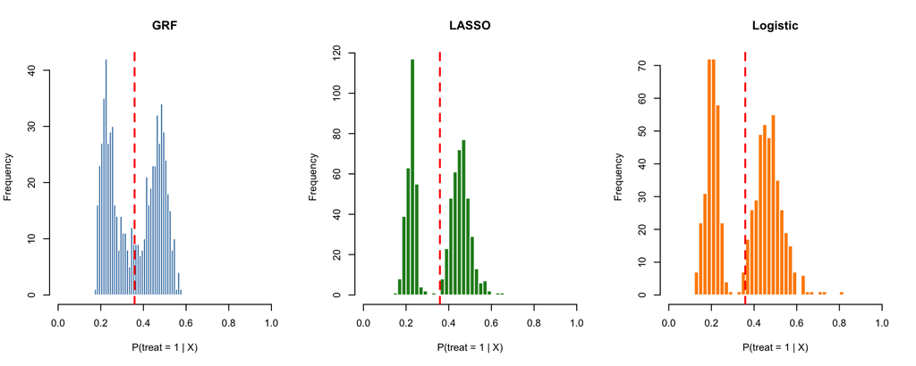

```r
par(mfrow = c(1, 3))
hist(ps_grf$ps_hat, breaks = 30, col = "steelblue", border = "white",
     main = "GRF", xlab = "P(treat = 1 | X)", xlim = c(0, 1))
abline(v = mean(df$hormon), col = "red", lwd = 2, lty = 2)
hist(ps_lasso$ps_hat, breaks = 30, col = "forestgreen", border = "white",
     main = "LASSO", xlab = "P(treat = 1 | X)", xlim = c(0, 1))
abline(v = mean(df$hormon), col = "red", lwd = 2, lty = 2)
hist(ps_logit$ps_hat, breaks = 30, col = "darkorange", border = "white",
     main = "Logistic", xlab = "P(treat = 1 | X)", xlim = c(0, 1))
abline(v = mean(df$hormon), col = "red", lwd = 2, lty = 2)
```

```r
par(mfrow = c(1, 1))
```

## 2.2 IPTW-Adjusted vs Unadjusted Estimates

```r
df_ps <- ps_grf$data

fn_unadj <- make_effect_estimator("binary", "hormon", "status",
  offset.name = "rfstime", effect_measure = "IRR",
  ps_adjust_method = "none")
fn_iptw <- make_effect_estimator("binary", "hormon", "status",
  offset.name = "rfstime", effect_measure = "IRR",
  ps_adjust_method = "iptw")

# ITT
res_u <- fn_unadj(df_ps)
res_a <- fn_iptw(df_ps)
cat("ITT Estimates:\n")
```

```
#> ITT Estimates:
```

```r
cat("  Unadjusted IRR:", round(exp(res_u$estimate), 3), "\n")
```

```
#>   Unadjusted IRR: 0.701
```

```r
cat("  IPTW-adjusted IRR:", round(exp(res_a$estimate), 3), "\n")
```

```
#>   IPTW-adjusted IRR: 0.679
```

```r
# Subgroup {er <= 0}
sg <- df_ps[df_ps$er <= 0, ]
res_u_sg <- fn_unadj(sg)
res_a_sg <- fn_iptw(sg)
cat("\nSubgroup {er <= 0}:\n")
```

```
#>
#> Subgroup {er <= 0}:
```

```r
cat("  Unadjusted IRR:", round(exp(res_u_sg$estimate), 3), "\n")
```

```
#>   Unadjusted IRR: 1.835
```

```r
cat("  IPTW-adjusted IRR:", round(exp(res_a_sg$estimate), 3), "\n")
```

```
#>   IPTW-adjusted IRR: 1.621
```

```r
# Complement {er > 0}
co <- df_ps[df_ps$er > 0, ]
res_u_co <- fn_unadj(co)
res_a_co <- fn_iptw(co)
cat("\nComplement {er > 0}:\n")
```

```
#>
#> Complement {er > 0}:
```

```r
cat("  Unadjusted IRR:", round(exp(res_u_co$estimate), 3), "\n")
```

```
#>   Unadjusted IRR: 0.627
```

```r
cat("  IPTW-adjusted IRR:", round(exp(res_a_co$estimate), 3), "\n")
```

```
#>   IPTW-adjusted IRR: 0.609
```

**Note**

In the GBSG RCT, IPTW adjustment has minimal impact because treatment was randomized. The benefit of PS adjustment is most apparent in observational data where confounding is present.

# 3 Simulation: Confounded Treatment Assignment

To demonstrate the value of IPTW adjustment, we simulate an observational study where treatment assignment depends on covariates (strong confounding).

## 3.1 Data-Generating Mechanism

```r
simulate_confounded_trial <- function(n = 2000, seed = 42L,
                                      confounding_strength = 1.5) {
  set.seed(seed)

  # Covariates
  x1 <- rbinom(n, 1, 0.5)
  x2 <- rbinom(n, 1, 0.5)
  x3 <- rnorm(n)
  x4 <- rnorm(n)

  # Confounded treatment: P(W=1) depends on x1 and x3
  # confounding_strength = 0 gives an RCT (constant PS)
  lp_treat <- -0.5 + confounding_strength *
    (0.6 * x1 + 0.8 * x3 + 0.2 * x1 * x3)
  ps_true <- plogis(lp_treat)
  treat   <- rbinom(n, 1, ps_true)

  # True subgroup: x1 == 1
  in_sg <- x1 == 1

  # Outcome: binary event with treatment-subgroup interaction
  # x3 is both a confounder AND a prognostic factor
  lp <- -1.0 + 0.5 * x3 + 0.3 * x4 +
        ifelse(in_sg, 0.8, -0.4) * treat
  event <- rbinom(n, 1, plogis(lp))

  # Follow-up time (for Poisson-offset)
  tte <- rexp(n, rate = 0.05) + 1

  data.frame(
    id = seq_len(n),
    x1 = x1, x2 = x2, x3 = x3, x4 = x4,
    treat = treat, event = event, tte = tte,
    in_sg = in_sg, ps_true = ps_true
  )
}

df_sim <- simulate_confounded_trial(n = 2000, seed = 42L,
                                    confounding_strength = 1.5)

cat("Simulated data (strong confounding):\n")
```

```
#> Simulated data (strong confounding):
```

```r
cat("  N =", nrow(df_sim), "\n")
```

```
#>   N = 2000
```

```r
cat("  P(treat=1):", round(mean(df_sim$treat), 3), "\n")
```

```
#>   P(treat=1): 0.481
```

```r
cat("  Event rate:", round(mean(df_sim$event), 3), "\n")
```

```
#>   Event rate: 0.311
```

```r
cat("  True subgroup {x1=1}: n =", sum(df_sim$in_sg),
    sprintf("(%.0f%%)\n", 100 * mean(df_sim$in_sg)))
```

```
#>   True subgroup {x1=1}: n = 977 (49%)
```

```r
cat("\nTrue PS range:", round(range(df_sim$ps_true), 3), "\n")
```

```
#>
#> True PS range: 0.012 0.994
```

```r
cat("  Mean PS (in_sg=TRUE):", round(mean(df_sim$ps_true[df_sim$in_sg]), 3), "\n")
```

```
#>   Mean PS (in_sg=TRUE): 0.554
```

```r
cat("  Mean PS (in_sg=FALSE):", round(mean(df_sim$ps_true[!df_sim$in_sg]), 3), "\n")
```

```
#>   Mean PS (in_sg=FALSE): 0.41
```

## 3.2 PS Estimation Quality

```r
confs_sim <- c("x1", "x2", "x3", "x4")

ps_sim_grf   <- estimate_propensity_scores(df_sim, "treat", confs_sim, method = "grf")
ps_sim_lasso <- estimate_propensity_scores(df_sim, "treat", confs_sim, method = "lasso")
ps_sim_logit <- estimate_propensity_scores(df_sim, "treat", confs_sim, method = "logistic")

cat("PS estimation quality (correlation with true PS):\n")
```

```
#> PS estimation quality (correlation with true PS):
```

```r
cat("  GRF:     ", round(cor(ps_sim_grf$ps_hat, df_sim$ps_true), 3), "\n")
```

```
#>   GRF:      0.986
```

```r
cat("  LASSO:   ", round(cor(ps_sim_lasso$ps_hat, df_sim$ps_true), 3), "\n")
```

```
#>   LASSO:    0.997
```

```r
cat("  Logistic:", round(cor(ps_sim_logit$ps_hat, df_sim$ps_true), 3), "\n")
```

```
#>   Logistic: 0.996
```

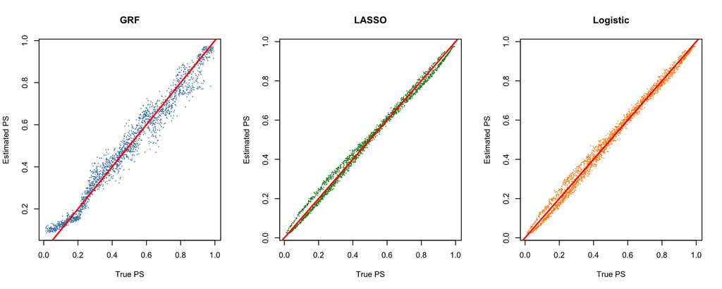

```r
par(mfrow = c(1, 3))
plot(df_sim$ps_true, ps_sim_grf$ps_hat, pch = 16, cex = 0.3, col = "steelblue",
     xlab = "True PS", ylab = "Estimated PS", main = "GRF")
abline(0, 1, col = "red", lwd = 2)
plot(df_sim$ps_true, ps_sim_lasso$ps_hat, pch = 16, cex = 0.3, col = "forestgreen",
     xlab = "True PS", ylab = "Estimated PS", main = "LASSO")
abline(0, 1, col = "red", lwd = 2)
plot(df_sim$ps_true, ps_sim_logit$ps_hat, pch = 16, cex = 0.3, col = "darkorange",
     xlab = "True PS", ylab = "Estimated PS", main = "Logistic")
abline(0, 1, col = "red", lwd = 2)
```

```r
par(mfrow = c(1, 1))
```

## 3.3 Single-Sample Bias Comparison

```r
# True treatment effects (from the DGM)
cat("True treatment effects (log-OR scale):\n")
```

```
#> True treatment effects (log-OR scale):
```

```r
cat("  Subgroup {x1=1}:   log-OR = 0.8  (OR = 2.23)\n")
```

```
#>   Subgroup {x1=1}:   log-OR = 0.8  (OR = 2.23)
```

```r
cat("  Complement {x1=0}: log-OR = -0.4  (OR = 0.67)\n\n")
```

```
#>   Complement {x1=0}: log-OR = -0.4  (OR = 0.67)
```

```r
df_ps_sim <- ps_sim_grf$data

# Build all three estimators
fn_u <- make_effect_estimator("binary", "treat", "event",
  effect_measure = "OR", ps_adjust_method = "none")
fn_iptw <- make_effect_estimator("binary", "treat", "event",
  effect_measure = "OR", ps_adjust_method = "iptw")
fn_dr <- make_effect_estimator("binary", "treat", "event",
  effect_measure = "OR", ps_adjust_method = "dr_gcomp")

# Subgroup
sg_sim <- df_ps_sim[df_ps_sim$x1 == 1, ]
co_sim <- df_ps_sim[df_ps_sim$x1 == 0, ]

cat("Subgroup {x1=1} (true OR = 2.23):\n")
```

```
#> Subgroup {x1=1} (true OR = 2.23):
```

```r
cat("  Unadjusted OR:    ", round(exp(fn_u(sg_sim)$estimate), 3), "\n")
```

```
#>   Unadjusted OR:     4.898
```

```r
cat("  IPTW OR:          ", round(exp(fn_iptw(sg_sim)$estimate), 3), "\n")
```

```
#>   IPTW OR:           2.67
```

```r
cat("  DR G-comp OR:     ", round(exp(fn_dr(sg_sim)$estimate), 3), "\n\n")
```

```
#>   DR G-comp OR:      5.24
```

```r
cat("Complement {x1=0} (true OR = 0.67):\n")
```

```
#> Complement {x1=0} (true OR = 0.67):
```

```r
cat("  Unadjusted OR:    ", round(exp(fn_u(co_sim)$estimate), 3), "\n")
```

```
#>   Unadjusted OR:     0.855
```

```r
cat("  IPTW OR:          ", round(exp(fn_iptw(co_sim)$estimate), 3), "\n")
```

```
#>   IPTW OR:           0.625
```

```r
cat("  DR G-comp OR:     ", round(exp(fn_dr(co_sim)$estimate), 3), "\n")
```

```
#>   DR G-comp OR:      0.836
```

**ImportantKey Observation**

The DR G-computation approach (IPS covariate from Section 2.2 of Bang & Robins, 2005) adds `1/f(W|X)` as a **covariate** (not a weight) to the outcome model. It does **not** use stabilized weights. The doubly-robust property requires confounders in the outcome model. ForestSearch intentionally uses treatment-only models (`Y ~ treat`) within subgroup slices, so the DR property does not hold and the IPS covariate provides no meaningful bias correction. IPTW does not have this limitation because it operates through weights rather than the outcome model specification.

## 3.4 Monte Carlo Evaluation

Two scenarios are evaluated:

- **Scenario 1 — Strong confounding** (`confounding_strength = 1.5`): Treatment assignment strongly depends on covariates that also affect the outcome. This is where PS adjustment matters.
- **Scenario 2 — No confounding / RCT** (`confounding_strength = 0`): Treatment is randomized. All methods should agree.

Four estimators are compared in each scenario:

1. **Unadjusted**: `glm(event ~ treat, family = binomial)`.
2. **IPTW (GRF PS)**: Stabilized IPTW weights from GRF-estimated PS.
3. **DR G-comp (GRF PS)**: Bang & Robins (2005) IPS covariate + G-computation (no stabilized weights; `1/f(W|X)` as covariate).
4. **IPTW (Oracle PS)**: Stabilized IPTW weights from the true PS (theoretical benchmark).

```r
n_sims <- 100
confs_sim <- c("x1", "x2", "x3", "x4")

# Configure parallel backend: 80% of available cores
# Using multisession (safe on macOS + RStudio).  Workers are fresh R
# processes that cannot see devtools::load_all() or source()'d files.
# We pass the path to glm_effect_estimators.R and source() it inside
# each worker body.
n_cores <- max(1L, floor(parallel::detectCores() * 0.80))
plan(multisession, workers = n_cores)
cat("Parallel backend: multisession with", n_cores, "workers\n")
```

```
#> Parallel backend: multisession with 11 workers
```

```r
# Resolve absolute path to the dev source file (workers need this)
pkg_root_abs <- normalizePath(pkg_root)
dev_source_path <- file.path(pkg_root_abs, "dev", "glm",
                             "glm_effect_estimators.R")
stopifnot(file.exists(dev_source_path))
cat("Dev source file:", dev_source_path, "\n")
```

```
#> Dev source file: /Users/larryleon/Documents/GitHub/forestsearch/dev/glm/glm_effect_estimators.R
```

```r
# Note: multisession workers are fresh R processes.  They do NOT have
# access to devtools::load_all() functions or source()'d dev files from
# the parent session.  We solve this by source()'ing the dev file
# inside each worker body.  simulate_confounded_trial() is defined in
# this Quarto session and is auto-exported by future's globals detection.

run_mc_scenario <- function(confounding_strength, n_sims, n = 2000) {

  results <- foreach(
    s = seq_len(n_sims),
    .combine = "rbind",
    .options.future = list(seed = TRUE),
    .errorhandling = "pass"
  ) %dofuture% {
    # Source dev file in worker (multisession workers are fresh processes)
    source(dev_source_path, local = TRUE)

    set.seed(s)

    df_s <- simulate_confounded_trial(n = n, seed = s,
              confounding_strength = confounding_strength)
    ps_s <- estimate_propensity_scores(df_s, "treat", confs_sim, method = "grf")
    df_s <- ps_s$data

    # Build estimators inside worker (closures are lightweight)
    fn_none <- make_effect_estimator("binary", "treat", "event",
      effect_measure = "OR", ps_adjust_method = "none")
    fn_iptw <- make_effect_estimator("binary", "treat", "event",
      effect_measure = "OR", ps_adjust_method = "iptw")
    fn_dr <- make_effect_estimator("binary", "treat", "event",
      effect_measure = "OR", ps_adjust_method = "dr_gcomp")

    # Oracle IPTW (true PS)
    p_treat <- mean(df_s$treat)
    df_s$sw_oracle <- ifelse(
      df_s$treat == 1,
      p_treat / df_s$ps_true,
      (1 - p_treat) / (1 - df_s$ps_true))

    sg <- df_s[df_s$x1 == 1, ]
    co <- df_s[df_s$x1 == 0, ]
    sg_orac <- sg; sg_orac$sw <- sg_orac$sw_oracle
    co_orac <- co; co_orac$sw <- co_orac$sw_oracle

    rbind(
      data.frame(sim = s, method = "1. Unadjusted",
        sg_est = fn_none(sg)$estimate, co_est = fn_none(co)$estimate),
      data.frame(sim = s, method = "2. IPTW (GRF PS)",
        sg_est = fn_iptw(sg)$estimate, co_est = fn_iptw(co)$estimate),
      data.frame(sim = s, method = "3. DR G-comp (IPS covar)",
        sg_est = fn_dr(sg)$estimate, co_est = fn_dr(co)$estimate),
      data.frame(sim = s, method = "4. IPTW (Oracle PS)",
        sg_est = fn_iptw(sg_orac)$estimate, co_est = fn_iptw(co_orac)$estimate)
    )
  }

  as.data.frame(results)
}

t_start <- proc.time()[3]

cat("Running Scenario 1: Strong confounding...\n")
```

```
#> Running Scenario 1: Strong confounding...
```

```r
res_confounded <- run_mc_scenario(confounding_strength = 1.5, n_sims = n_sims)

cat("Running Scenario 2: No confounding (RCT)...\n")
```

```
#> Running Scenario 2: No confounding (RCT)...
```

```r
res_rct <- run_mc_scenario(confounding_strength = 0.0, n_sims = n_sims)

t_elapsed <- proc.time()[3] - t_start
cat(sprintf("\nBoth scenarios completed in %.1f minutes (%.0f seconds)\n",
            t_elapsed / 60, t_elapsed))
```

```
#>
#> Both scenarios completed in 0.5 minutes (33 seconds)
```

```r
cat(sprintf("  %d sims/scenario × 2 scenarios = %d total iterations\n",
            n_sims, 2 * n_sims))
```

```
#>   100 sims/scenario × 2 scenarios = 200 total iterations
```

```r
cat(sprintf("  Workers: %d cores\n", n_cores))
```

```
#>   Workers: 11 cores
```

```r
# Reset to sequential
plan(sequential)
```

### 3.4.1 Summary Table: Strong Confounding

```r
make_summary_table <- function(results, true_sg, true_co, title, subtitle) {
  methods <- unique(results$method)
  summary_rows <- lapply(methods, function(m) {
    sg <- results$sg_est[results$method == m]
    co <- results$co_est[results$method == m]
    data.frame(
      Method   = m,
      SG_Mean  = round(mean(sg, na.rm = TRUE), 3),
      SG_Bias  = round(mean(sg, na.rm = TRUE) - true_sg, 3),
      SG_RMSE  = round(sqrt(mean((sg - true_sg)^2, na.rm = TRUE)), 3),
      CO_Mean  = round(mean(co, na.rm = TRUE), 3),
      CO_Bias  = round(mean(co, na.rm = TRUE) - true_co, 3),
      CO_RMSE  = round(sqrt(mean((co - true_co)^2, na.rm = TRUE)), 3),
      stringsAsFactors = FALSE
    )
  })
  summary_df <- do.call(rbind, summary_rows)

  gt(summary_df) |>
    tab_header(title = md(title), subtitle = subtitle) |>
    tab_spanner(label = "Subgroup {x1=1} (true = 0.80)",
                columns = c(SG_Mean, SG_Bias, SG_RMSE)) |>
    tab_spanner(label = "Complement {x1=0} (true = -0.40)",
                columns = c(CO_Mean, CO_Bias, CO_RMSE)) |>
    cols_label(
      Method = "Method",
      SG_Mean = "Mean", SG_Bias = "Bias", SG_RMSE = "RMSE",
      CO_Mean = "Mean", CO_Bias = "Bias", CO_RMSE = "RMSE"
    ) |>
    tab_style(
      style = cell_fill(color = "#e8f5e9"),
      locations = cells_body(rows = grepl("2\\. IPTW", Method))
    ) |>
    tab_style(
      style = cell_fill(color = "#fff3e0"),
      locations = cells_body(rows = grepl("3\\. DR", Method))
    ) |>
    tab_style(
      style = cell_fill(color = "#e3f2fd"),
      locations = cells_body(rows = grepl("4\\. IPTW.*Oracle", Method))
    ) |>
    tab_source_note(md(paste0(
      "Green = IPTW with estimated PS (recommended). ",
      "Orange = DR G-comp (IPS covariate, no stabilized weights). ",
      "Blue = Oracle IPTW (true PS, benchmark)."
    )))
}

make_summary_table(
  res_confounded, true_sg = 0.8, true_co = -0.4,
  title = "**Scenario 1: Strong Confounding**",
  subtitle = sprintf("%d simulations, N = 2000, confounding strength = 1.5",
                     n_sims)
)
```

**Scenario 1: Strong Confounding**

100 simulations, N = 2000, confounding strength = 1.5

| Method | Subgroup {x1=1} (true = 0.80) Mean | Subgroup {x1=1} (true = 0.80) Bias | Subgroup {x1=1} (true = 0.80) RMSE | Complement {x1=0} (true = -0.40) Mean | Complement {x1=0} (true = -0.40) Bias | Complement {x1=0} (true = -0.40) RMSE |
| --- | --- | --- | --- | --- | --- | --- |
| 1. Unadjusted | 1.253 | 0.453 | 0.473 | 0.051 | 0.451 | 0.476 |
| 2. IPTW (GRF PS) | 0.795 | -0.005 | 0.195 | -0.333 | 0.067 | 0.189 |
| 3. DR G-comp (IPS covar) | 1.248 | 0.448 | 0.473 | 0.046 | 0.446 | 0.471 |
| 4. IPTW (Oracle PS) | 0.760 | -0.040 | 0.208 | -0.370 | 0.030 | 0.190 |

Green = IPTW with estimated PS (recommended). Orange = DR G-comp (IPS covariate, no stabilized weights). Blue = Oracle IPTW (true PS, benchmark).

### 3.4.2 Summary Table: No Confounding (RCT)

```r
make_summary_table(
  res_rct, true_sg = 0.8, true_co = -0.4,
  title = "**Scenario 2: No Confounding (RCT Benchmark)**",
  subtitle = sprintf("%d simulations, N = 2000, confounding strength = 0",
                     n_sims)
)
```

**Scenario 2: No Confounding (RCT Benchmark)**

100 simulations, N = 2000, confounding strength = 0

| Method | Subgroup {x1=1} (true = 0.80) Mean | Subgroup {x1=1} (true = 0.80) Bias | Subgroup {x1=1} (true = 0.80) RMSE | Complement {x1=0} (true = -0.40) Mean | Complement {x1=0} (true = -0.40) Bias | Complement {x1=0} (true = -0.40) RMSE |
| --- | --- | --- | --- | --- | --- | --- |
| 1. Unadjusted | 0.727 | -0.073 | 0.147 | -0.417 | -0.017 | 0.158 |
| 2. IPTW (GRF PS) | 0.728 | -0.072 | 0.146 | -0.414 | -0.014 | 0.157 |
| 3. DR G-comp (IPS covar) | 0.727 | -0.073 | 0.147 | -0.417 | -0.017 | 0.157 |
| 4. IPTW (Oracle PS) | 0.727 | -0.073 | 0.147 | -0.417 | -0.017 | 0.158 |

Green = IPTW with estimated PS (recommended). Orange = DR G-comp (IPS covariate, no stabilized weights). Blue = Oracle IPTW (true PS, benchmark).

**Note**

Under zero confounding, all four estimators should be approximately unbiased. IPTW may show slightly increased variance due to the weighting, but bias should be near zero.

### 3.4.3 Subgroup Boxplot: Strong Confounding

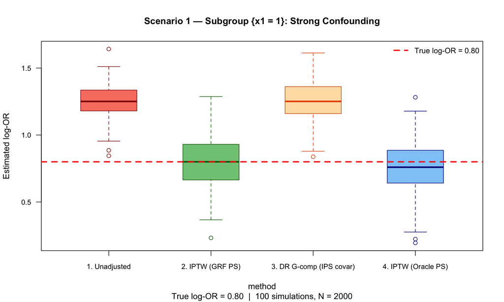

```r
boxplot(sg_est ~ method, data = res_confounded,
        main = "Scenario 1 — Subgroup {x1 = 1}: Strong Confounding",
        sub = sprintf("True log-OR = 0.80  |  %d simulations, N = 2000",
                       n_sims),
        ylab = "Estimated log-OR",
        col = c("salmon", "#81C784", "#FFE0B2", "#90CAF9"),
        las = 1, cex.axis = 0.85, cex.main = 1.1,
        boxwex = 0.55, staplewex = 0.4,
        border = c("darkred", "darkgreen", "#E65100", "darkblue"))
abline(h = 0.8, col = "red", lwd = 2.5, lty = 2)
legend("topright",
       legend = "True log-OR = 0.80",
       col = "red", lty = 2, lwd = 2.5, bty = "n", cex = 0.9)
```

### 3.4.4 Complement Boxplot: Strong Confounding

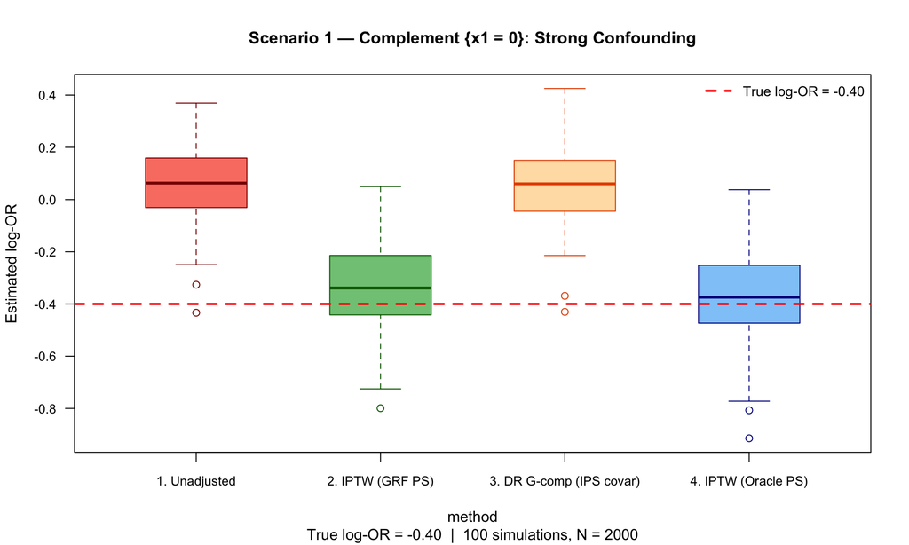

```r
boxplot(co_est ~ method, data = res_confounded,
        main = "Scenario 1 — Complement {x1 = 0}: Strong Confounding",
        sub = sprintf("True log-OR = -0.40  |  %d simulations, N = 2000",
                       n_sims),
        ylab = "Estimated log-OR",
        col = c("salmon", "#81C784", "#FFE0B2", "#90CAF9"),
        las = 1, cex.axis = 0.85, cex.main = 1.1,
        boxwex = 0.55, staplewex = 0.4,
        border = c("darkred", "darkgreen", "#E65100", "darkblue"))
abline(h = -0.4, col = "red", lwd = 2.5, lty = 2)
legend("topright",
       legend = "True log-OR = -0.40",
       col = "red", lty = 2, lwd = 2.5, bty = "n", cex = 0.9)
```

### 3.4.5 Subgroup Boxplot: No Confounding (RCT)

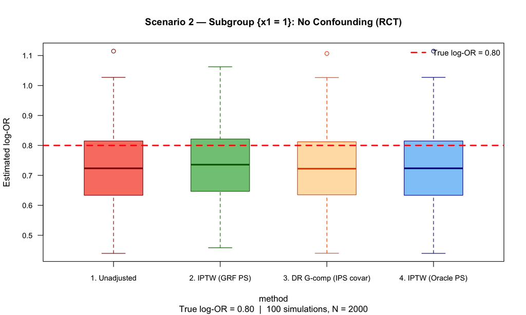

```r
boxplot(sg_est ~ method, data = res_rct,
        main = "Scenario 2 — Subgroup {x1 = 1}: No Confounding (RCT)",
        sub = sprintf("True log-OR = 0.80  |  %d simulations, N = 2000",
                       n_sims),
        ylab = "Estimated log-OR",
        col = c("salmon", "#81C784", "#FFE0B2", "#90CAF9"),
        las = 1, cex.axis = 0.85, cex.main = 1.1,
        boxwex = 0.55, staplewex = 0.4,
        border = c("darkred", "darkgreen", "#E65100", "darkblue"))
abline(h = 0.8, col = "red", lwd = 2.5, lty = 2)
legend("topright",
       legend = "True log-OR = 0.80",
       col = "red", lty = 2, lwd = 2.5, bty = "n", cex = 0.9)
```

### 3.4.6 Complement Boxplot: No Confounding (RCT)

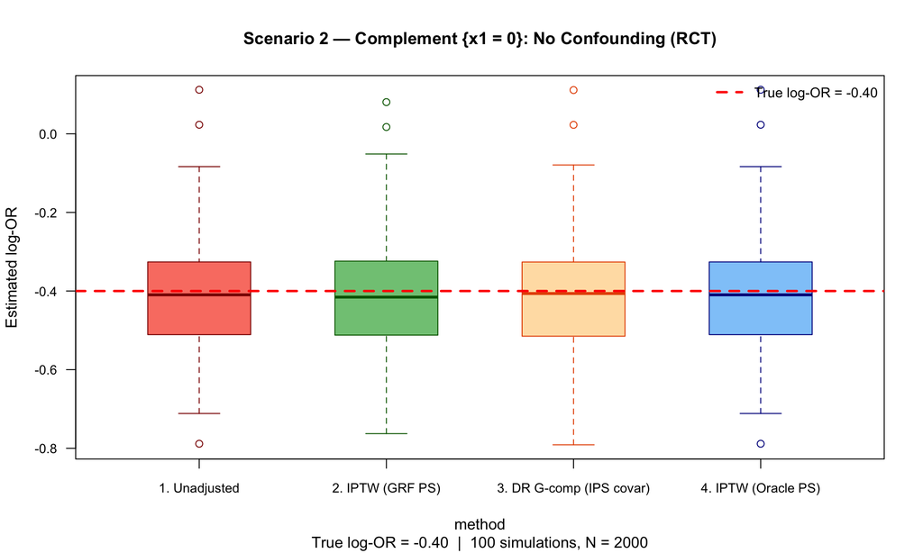

```r
boxplot(co_est ~ method, data = res_rct,
        main = "Scenario 2 — Complement {x1 = 0}: No Confounding (RCT)",
        sub = sprintf("True log-OR = -0.40  |  %d simulations, N = 2000",
                       n_sims),
        ylab = "Estimated log-OR",
        col = c("salmon", "#81C784", "#FFE0B2", "#90CAF9"),
        las = 1, cex.axis = 0.85, cex.main = 1.1,
        boxwex = 0.55, staplewex = 0.4,
        border = c("darkred", "darkgreen", "#E65100", "darkblue"))
abline(h = -0.4, col = "red", lwd = 2.5, lty = 2)
legend("topright",
       legend = "True log-OR = -0.40",
       col = "red", lty = 2, lwd = 2.5, bty = "n", cex = 0.9)
```

### 3.4.7 Bias Reduction: Paired Comparison (Strong Confounding)

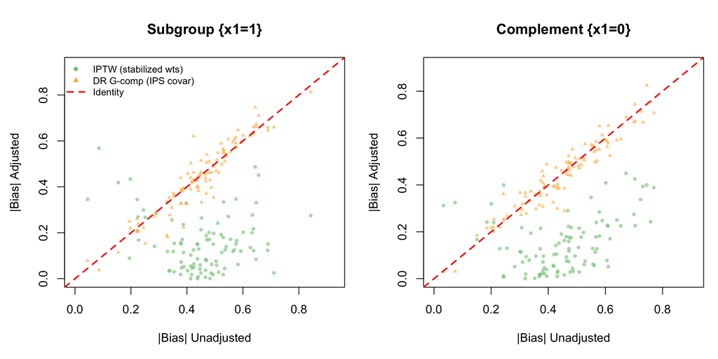

```r
# Compare |bias| for unadjusted vs IPTW vs DR G-comp
unadj_sg <- res_confounded$sg_est[res_confounded$method == "1. Unadjusted"]
iptw_sg  <- res_confounded$sg_est[res_confounded$method == "2. IPTW (GRF PS)"]
dr_sg    <- res_confounded$sg_est[res_confounded$method == "3. DR G-comp (IPS covar)"]
unadj_co <- res_confounded$co_est[res_confounded$method == "1. Unadjusted"]
iptw_co  <- res_confounded$co_est[res_confounded$method == "2. IPTW (GRF PS)"]
dr_co    <- res_confounded$co_est[res_confounded$method == "3. DR G-comp (IPS covar)"]

par(mfrow = c(1, 2), mar = c(5, 4.5, 4, 1))

# Subgroup: IPTW vs DR G-comp
max_x <- max(abs(unadj_sg - 0.8), abs(iptw_sg - 0.8),
             abs(dr_sg - 0.8), na.rm = TRUE) * 1.1
plot(abs(unadj_sg - 0.8), abs(iptw_sg - 0.8),
     pch = 16, cex = 0.7, col = adjustcolor("#81C784", 0.6),
     xlab = "|Bias| Unadjusted", ylab = "|Bias| Adjusted",
     main = "Subgroup {x1=1}",
     xlim = c(0, max_x), ylim = c(0, max_x))
points(abs(unadj_sg - 0.8), abs(dr_sg - 0.8),
       pch = 17, cex = 0.6, col = adjustcolor("#FFB74D", 0.6))
abline(0, 1, col = "red", lwd = 2, lty = 2)
legend("topleft",
       legend = c("IPTW (stabilized wts)", "DR G-comp (IPS covar)", "Identity"),
       col = c("#81C784", "#FFB74D", "red"),
       pch = c(16, 17, NA), lty = c(NA, NA, 2), lwd = c(NA, NA, 2),
       bty = "n", cex = 0.8)

# Complement
max_x2 <- max(abs(unadj_co + 0.4), abs(iptw_co + 0.4),
              abs(dr_co + 0.4), na.rm = TRUE) * 1.1
plot(abs(unadj_co + 0.4), abs(iptw_co + 0.4),
     pch = 16, cex = 0.7, col = adjustcolor("#81C784", 0.6),
     xlab = "|Bias| Unadjusted", ylab = "|Bias| Adjusted",
     main = "Complement {x1=0}",
     xlim = c(0, max_x2), ylim = c(0, max_x2))
points(abs(unadj_co + 0.4), abs(dr_co + 0.4),
       pch = 17, cex = 0.6, col = adjustcolor("#FFB74D", 0.6))
abline(0, 1, col = "red", lwd = 2, lty = 2)
```

```r
pct_iptw_sg <- round(100 * mean(abs(iptw_sg - 0.8) < abs(unadj_sg - 0.8),
                                na.rm = TRUE), 0)
pct_dr_sg <- round(100 * mean(abs(dr_sg - 0.8) < abs(unadj_sg - 0.8),
                              na.rm = TRUE), 0)
pct_iptw_co <- round(100 * mean(abs(iptw_co + 0.4) < abs(unadj_co + 0.4),
                                na.rm = TRUE), 0)
pct_dr_co <- round(100 * mean(abs(dr_co + 0.4) < abs(unadj_co + 0.4),
                              na.rm = TRUE), 0)

par(mfrow = c(1, 1))

cat("Subgroup: IPTW reduces |bias| in", pct_iptw_sg,
    "% of sims; DR G-comp in", pct_dr_sg, "%\n")
```

```
#> Subgroup: IPTW reduces |bias| in 91 % of sims; DR G-comp in 49 %
```

```r
cat("Complement: IPTW reduces |bias| in", pct_iptw_co,
    "% of sims; DR G-comp in", pct_dr_co, "%\n")
```

```
#> Complement: IPTW reduces |bias| in 93 % of sims; DR G-comp in 52 %
```

# 4 Integration with ForestSearch

## 4.1 API Usage

```r
# RCT (default: no PS adjustment)
forestsearch(df, outcome_type = "binary", effect_measure = "IRR",
             dmin.grf = 0.0, ...)

# Observational with IPTW (default when is.RCT = FALSE)
forestsearch(df, outcome_type = "binary", effect_measure = "IRR",
             dmin.grf = 0.0, is.RCT = FALSE,
             ps_method = "grf", ps_adjust_method = "iptw", ...)

# Observational with LASSO PS
forestsearch(df, outcome_type = "binary", is.RCT = FALSE,
             ps_method = "lasso", ps_adjust_method = "iptw", ...)

# User-supplied PS
forestsearch(df, outcome_type = "binary", is.RCT = FALSE,
             ps_hat = my_ps_vector, ps_adjust_method = "iptw", ...)
```

## 4.2 Key Design Decisions

1. **Stabilized IPTW, not IPS covariate.** The stabilized weights $\text{sw} = P(W) / \hat{e}(X)$ for treated (and analogously for control) create a pseudo-population where treatment is independent of confounders. The treatment coefficient from `glm(Y ~ treat, weights = sw)` **is** the marginal causal effect. This approach does not require confounders in the outcome model, making it compatible with ForestSearch’s treatment-only subgroup estimation architecture.
2. **Full-sample PS used within subgroups.** Propensity scores are estimated once on the full sample and carried into subgroup slices as-is. The PS is a design quantity reflecting the treatment assignment mechanism — re-estimating within slices would be methodologically incorrect and statistically unstable.
3. **GRF PS from the screening step.** When `use_grf = TRUE`, the causal forest already estimates `W.hat`. The `grf.subg.harm.glm()` function now returns the fitted forest object, enabling PS extraction without re-estimation.
4. **Trimming.** PS values are trimmed to [2.5%, 97.5%] before computing stabilized weights, preventing extreme values in subgroup slices where one treatment arm dominates.
5. **Backward compatibility.** For `is.RCT = TRUE` (default), `ps_method` resolves to `"none"` and the estimator closure is identical to the unadjusted version. Existing analyses are unaffected.